multiple myeloma

# Modeling dissemination of multiple myeloma in vivo

## Abstract

Clonal evolution drives tumor progression, dissemination and relapse in multiple myeloma (MM), with most patients dying of relapsed disease. This multi-stage process requires tumor cells to enter the circulation, extravasate and colonize distant bone marrow (BM) sites. Here, we developed a fluorescent or DNA-barcode clone-tracking system on MM PrEDiCT (Progression through Evolution and Dissemination of Clonal Tumor cells) xenograft mouse model to study clonal behavior within the BM microenvironment. We showed that only the few clones that successfully adapt to the BM microenvironment can enter the circulation and colonize distant BM sites. RNA-sequencing of primary and distant-site MM tumor cells revealed a progression signature sequentially activated along human MM progression and significantly associated with overall survival when evaluated against patient datasets. 28 genes were then computationally predicted to be master regulators (MRs) of MM progression. HMGA1 and PA2G4 were validated in vivo using CRISPR/Cas9 in PrEDiCT model and were shown to be significantly depleted in distant BM sites indicating their role in MM progression and dissemination. Loss of HMGA1 and PA2G4 also compromised the proliferation, migration and adhesion abilities of MM cells in vitro. Overall, our model successfully recapitulates key characteristics of human MM disease progression and identified potential new therapeutic targets for MM.

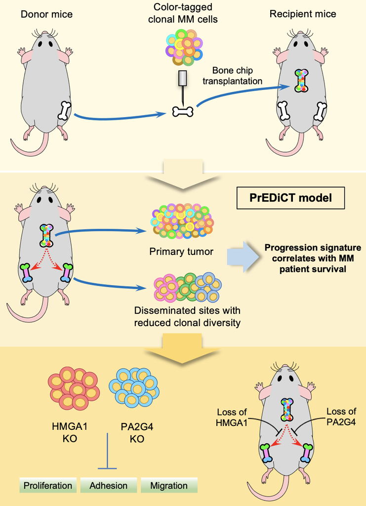